# ANCOVA in Vocabulario Ensinado (Vocabulario Ensinado)

Geiser C. Challco geiser@alumni.usp.br

- Descriptive Statistics of Initial Data
- ANCOVA and Pairwise for one factor: **grupo**
  - Without remove non-normal data
  - Computing ANCOVA and PairWise After removing non-normal data (OK)
    - Plots for ancova
    - Checking linearity assumption
    - Checking normality and homogeneity
- ANCOVA and Pairwise for two factors **grupo:Sexo**
  - Without remove non-normal data
  - Computing ANCOVA and PairWise After removing non-normal data (OK)
    - Plots for ancova
    - Checking linearity assumption
    - Checking normality and homogeneity
- ANCOVA and Pairwise for two factors **grupo:Zona**
  - Without remove non-normal data
  - Computing ANCOVA and PairWise After removing non-normal data (OK)
    - Plots for ancova
    - Checking linearity assumption
    - Checking normality and homogeneity
- ANCOVA and Pairwise for two factors **grupo:Cor.Raca**
  - Without remove non-normal data
  - Computing ANCOVA and PairWise After removing non-normal data (OK)
    - Plots for ancova
    - Checking linearity assumption
    - Checking normality and homogeneity
- ANCOVA and Pairwise for two factors **grupo:Serie**
  - Without remove non-normal data
  - Computing ANCOVA and PairWise After removing non-normal data (OK)
    - Plots for ancova
    - Checking linearity assumption
    - Checking normality and homogeneity
- Summary of Results
  - Descriptive Statistics
  - ANCOVA Table Comparison
  - PairWise Table Comparison
  - EMMS Table Comparison

**NOTE**:

- Teste ANCOVA para determinar se houve diferenças significativas no Vocabulario Ensinado (medido usando pre- e pos-testes).
- ANCOVA test to determine whether there were significant differences in Vocabulario Ensinado (measured using pre- and post-tests).

# Descriptive Statistics of Initial Data

```r
df <- get.descriptives(dat, c(dv.pre, dv.pos), c("grupo"),
                       include.global = T, symmetry.test = T, normality.test = F)
df <- plyr::rbind.fill(
  df, do.call(plyr::rbind.fill, lapply(lfatores2, FUN = function(f) {
    if (nrow(dat) > 0 && sum(!is.na(unique(dat[[f]]))) > 1)
      get.descriptives(dat, c(dv.pre,dv.pos), c("grupo", f),
                       symmetry.test = T, normality.test = F)
    }))
)
(df <- df[,c(fatores1[fatores1 %in% colnames(df)],"variable",
             colnames(df)[!colnames(df) %in% c(fatores1,"variable")])])
```

```
##           grupo Sexo   Zona Cor.Raca Serie        variable   n  mean median min max    sd    se    ci  iqr
## 1      Controle <NA>   <NA>     <NA>  <NA> vocab.teach.pre  80 3.000    3.0   3   3 0.000 0.000 0.000 0.00
## 2  Experimental <NA>   <NA>     <NA>  <NA> vocab.teach.pre 105 3.000    3.0   3   3 0.000 0.000 0.000 0.00
## 3          <NA> <NA>   <NA>     <NA>  <NA> vocab.teach.pre 185 3.000    3.0   3   3 0.000 0.000 0.000 0.00
## 4      Controle <NA>   <NA>     <NA>  <NA> vocab.teach.pos  80 4.138    4.0   0   9 1.674 0.187 0.373 2.00
## 5  Experimental <NA>   <NA>     <NA>  <NA> vocab.teach.pos 105 4.686    5.0   1   9 1.723 0.168 0.333 3.00
## 6          <NA> <NA>   <NA>     <NA>  <NA> vocab.teach.pos 185 4.449    4.0   0   9 1.719 0.126 0.249 3.00
## 7      Controle    F   <NA>     <NA>  <NA> vocab.teach.pre  38 3.000    3.0   3   3 0.000 0.000 0.000 0.00
## 8      Controle    M   <NA>     <NA>  <NA> vocab.teach.pre  42 3.000    3.0   3   3 0.000 0.000 0.000 0.00
## 9  Experimental    F   <NA>     <NA>  <NA> vocab.teach.pre  52 3.000    3.0   3   3 0.000 0.000 0.000 0.00
## 10 Experimental    M   <NA>     <NA>  <NA> vocab.teach.pre  53 3.000    3.0   3   3 0.000 0.000 0.000 0.00
## 11     Controle    F   <NA>     <NA>  <NA> vocab.teach.pos  38 4.053    4.0   1   7 1.576 0.256 0.518 2.00
## 12     Controle    M   <NA>     <NA>  <NA> vocab.teach.pos  42 4.214    4.0   0   9 1.774 0.274 0.553 2.00
## 13 Experimental    F   <NA>     <NA>  <NA> vocab.teach.pos  52 4.885    5.0   1   9 1.745 0.242 0.486 2.00
## 14 Experimental    M   <NA>     <NA>  <NA> vocab.teach.pos  53 4.491    4.0   1   7 1.694 0.233 0.467 3.00
```

[output cut: 98 more lines]

| grupo | Sexo | Zona | Cor.Raca | Serie | variable | n | mean | median | min | max | sd | se | ci | iqr | symmetry | skewness | kurtosis |
| --- | --- | --- | --- | --- | --- | --- | --- | --- | --- | --- | --- | --- | --- | --- | --- | --- | --- |
| Controle |  |  |  |  | vocab.teach.pre | 80 | 3.000 | 3.0 | 3 | 3 | 0.000 | 0.000 | 0.000 | 0.00 | few data | 0.000 | 0.000 |
| Experimental |  |  |  |  | vocab.teach.pre | 105 | 3.000 | 3.0 | 3 | 3 | 0.000 | 0.000 | 0.000 | 0.00 | few data | 0.000 | 0.000 |
|  |  |  |  |  | vocab.teach.pre | 185 | 3.000 | 3.0 | 3 | 3 | 0.000 | 0.000 | 0.000 | 0.00 | few data | 0.000 | 0.000 |
| Controle |  |  |  |  | vocab.teach.pos | 80 | 4.138 | 4.0 | 0 | 9 | 1.674 | 0.187 | 0.373 | 2.00 | YES | 0.265 | 0.205 |
| Experimental |  |  |  |  | vocab.teach.pos | 105 | 4.686 | 5.0 | 1 | 9 | 1.723 | 0.168 | 0.333 | 3.00 | YES | 0.107 | -0.648 |
|  |  |  |  |  | vocab.teach.pos | 185 | 4.449 | 4.0 | 0 | 9 | 1.719 | 0.126 | 0.249 | 3.00 | YES | 0.179 | -0.305 |
| Controle | F |  |  |  | vocab.teach.pre | 38 | 3.000 | 3.0 | 3 | 3 | 0.000 | 0.000 | 0.000 | 0.00 | few data | 0.000 | 0.000 |
| Controle | M |  |  |  | vocab.teach.pre | 42 | 3.000 | 3.0 | 3 | 3 | 0.000 | 0.000 | 0.000 | 0.00 | few data | 0.000 | 0.000 |
| Experimental | F |  |  |  | vocab.teach.pre | 52 | 3.000 | 3.0 | 3 | 3 | 0.000 | 0.000 | 0.000 | 0.00 | few data | 0.000 | 0.000 |
| Experimental | M |  |  |  | vocab.teach.pre | 53 | 3.000 | 3.0 | 3 | 3 | 0.000 | 0.000 | 0.000 | 0.00 | few data | 0.000 | 0.000 |
| Controle | F |  |  |  | vocab.teach.pos | 38 | 4.053 | 4.0 | 1 | 7 | 1.576 | 0.256 | 0.518 | 2.00 | YES | -0.124 | -0.806 |
| Controle | M |  |  |  | vocab.teach.pos | 42 | 4.214 | 4.0 | 0 | 9 | 1.774 | 0.274 | 0.553 | 2.00 | YES | 0.476 | 0.488 |
| Experimental | F |  |  |  | vocab.teach.pos | 52 | 4.885 | 5.0 | 1 | 9 | 1.745 | 0.242 | 0.486 | 2.00 | YES | 0.217 | -0.505 |
| Experimental | M |  |  |  | vocab.teach.pos | 53 | 4.491 | 4.0 | 1 | 7 | 1.694 | 0.233 | 0.467 | 3.00 | YES | -0.031 | -1.060 |
| Controle |  | Rural |  |  | vocab.teach.pre | 42 | 3.000 | 3.0 | 3 | 3 | 0.000 | 0.000 | 0.000 | 0.00 | few data | 0.000 | 0.000 |
| Controle |  | Urbana |  |  | vocab.teach.pre | 18 | 3.000 | 3.0 | 3 | 3 | 0.000 | 0.000 | 0.000 | 0.00 | few data | 0.000 | 0.000 |
| Controle |  |  |  |  | vocab.teach.pre | 20 | 3.000 | 3.0 | 3 | 3 | 0.000 | 0.000 | 0.000 | 0.00 | few data | 0.000 | 0.000 |
| Experimental |  | Rural |  |  | vocab.teach.pre | 40 | 3.000 | 3.0 | 3 | 3 | 0.000 | 0.000 | 0.000 | 0.00 | few data | 0.000 | 0.000 |
| Experimental |  | Urbana |  |  | vocab.teach.pre | 28 | 3.000 | 3.0 | 3 | 3 | 0.000 | 0.000 | 0.000 | 0.00 | few data | 0.000 | 0.000 |
| Experimental |  |  |  |  | vocab.teach.pre | 37 | 3.000 | 3.0 | 3 | 3 | 0.000 | 0.000 | 0.000 | 0.00 | few data | 0.000 | 0.000 |
| Controle |  | Rural |  |  | vocab.teach.pos | 42 | 3.929 | 4.0 | 0 | 9 | 1.759 | 0.271 | 0.548 | 2.00 | NO | 0.631 | 0.636 |
| Controle |  | Urbana |  |  | vocab.teach.pos | 18 | 4.500 | 4.5 | 2 | 7 | 1.425 | 0.336 | 0.708 | 1.75 | YES | -0.173 | -1.002 |
| Controle |  |  |  |  | vocab.teach.pos | 20 | 4.250 | 4.0 | 1 | 8 | 1.713 | 0.383 | 0.802 | 1.25 | YES | -0.131 | -0.206 |
| Experimental |  | Rural |  |  | vocab.teach.pos | 40 | 4.575 | 4.5 | 1 | 9 | 1.920 | 0.304 | 0.614 | 3.00 | YES | 0.259 | -0.795 |
| Experimental |  | Urbana |  |  | vocab.teach.pos | 28 | 4.821 | 5.0 | 1 | 8 | 1.701 | 0.321 | 0.660 | 2.00 | YES | -0.254 | -0.580 |
| Experimental |  |  |  |  | vocab.teach.pos | 37 | 4.703 | 5.0 | 2 | 8 | 1.543 | 0.254 | 0.515 | 2.00 | YES | 0.224 | -0.906 |
| Controle |  |  | Branca |  | vocab.teach.pre | 7 | 3.000 | 3.0 | 3 | 3 | 0.000 | 0.000 | 0.000 | 0.00 | few data | 0.000 | 0.000 |
| Controle |  |  | Indígena |  | vocab.teach.pre | 1 | 3.000 | 3.0 | 3 | 3 |  |  |  | 0.00 | few data | 0.000 | 0.000 |
| Controle |  |  | Parda |  | vocab.teach.pre | 30 | 3.000 | 3.0 | 3 | 3 | 0.000 | 0.000 | 0.000 | 0.00 | few data | 0.000 | 0.000 |
| Controle |  |  | Preta |  | vocab.teach.pre | 1 | 3.000 | 3.0 | 3 | 3 |  |  |  | 0.00 | few data | 0.000 | 0.000 |
| Controle |  |  |  |  | vocab.teach.pre | 41 | 3.000 | 3.0 | 3 | 3 | 0.000 | 0.000 | 0.000 | 0.00 | few data | 0.000 | 0.000 |
| Experimental |  |  | Amarela |  | vocab.teach.pre | 1 | 3.000 | 3.0 | 3 | 3 |  |  |  | 0.00 | few data | 0.000 | 0.000 |
| Experimental |  |  | Branca |  | vocab.teach.pre | 6 | 3.000 | 3.0 | 3 | 3 | 0.000 | 0.000 | 0.000 | 0.00 | few data | 0.000 | 0.000 |
| Experimental |  |  | Indígena |  | vocab.teach.pre | 1 | 3.000 | 3.0 | 3 | 3 |  |  |  | 0.00 | few data | 0.000 | 0.000 |
| Experimental |  |  | Parda |  | vocab.teach.pre | 37 | 3.000 | 3.0 | 3 | 3 | 0.000 | 0.000 | 0.000 | 0.00 | few data | 0.000 | 0.000 |
| Experimental |  |  |  |  | vocab.teach.pre | 60 | 3.000 | 3.0 | 3 | 3 | 0.000 | 0.000 | 0.000 | 0.00 | few data | 0.000 | 0.000 |
| Controle |  |  | Branca |  | vocab.teach.pos | 7 | 4.286 | 4.0 | 2 | 7 | 1.890 | 0.714 | 1.748 | 2.50 | YES | 0.031 | -1.681 |
| Controle |  |  | Indígena |  | vocab.teach.pos | 1 | 6.000 | 6.0 | 6 | 6 |  |  |  | 0.00 | few data | 0.000 | 0.000 |
| Controle |  |  | Parda |  | vocab.teach.pos | 30 | 4.300 | 4.0 | 2 | 9 | 1.601 | 0.292 | 0.598 | 2.00 | NO | 0.693 | 0.566 |
| Controle |  |  | Preta |  | vocab.teach.pos | 1 | 6.000 | 6.0 | 6 | 6 |  |  |  | 0.00 | few data | 0.000 | 0.000 |
| Controle |  |  |  |  | vocab.teach.pos | 41 | 3.902 | 4.0 | 0 | 8 | 1.700 | 0.266 | 0.537 | 2.00 | YES | 0.178 | 0.198 |
| Experimental |  |  | Amarela |  | vocab.teach.pos | 1 | 6.000 | 6.0 | 6 | 6 |  |  |  | 0.00 | few data | 0.000 | 0.000 |
| Experimental |  |  | Branca |  | vocab.teach.pos | 6 | 4.333 | 3.5 | 2 | 7 | 2.160 | 0.882 | 2.267 | 3.25 | YES | 0.338 | -1.951 |
| Experimental |  |  | Indígena |  | vocab.teach.pos | 1 | 7.000 | 7.0 | 7 | 7 |  |  |  | 0.00 | few data | 0.000 | 0.000 |
| Experimental |  |  | Parda |  | vocab.teach.pos | 37 | 5.162 | 5.0 | 2 | 8 | 1.519 | 0.250 | 0.506 | 2.00 | YES | 0.150 | -0.692 |
| Experimental |  |  |  |  | vocab.teach.pos | 60 | 4.367 | 4.0 | 1 | 9 | 1.746 | 0.225 | 0.451 | 2.25 | YES | 0.248 | -0.488 |
| Controle |  |  |  | 6 ano | vocab.teach.pre | 25 | 3.000 | 3.0 | 3 | 3 | 0.000 | 0.000 | 0.000 | 0.00 | few data | 0.000 | 0.000 |
| Controle |  |  |  | 7 ano | vocab.teach.pre | 33 | 3.000 | 3.0 | 3 | 3 | 0.000 | 0.000 | 0.000 | 0.00 | few data | 0.000 | 0.000 |
| Controle |  |  |  | 8 ano | vocab.teach.pre | 12 | 3.000 | 3.0 | 3 | 3 | 0.000 | 0.000 | 0.000 | 0.00 | few data | 0.000 | 0.000 |
| Controle |  |  |  | 9 ano | vocab.teach.pre | 10 | 3.000 | 3.0 | 3 | 3 | 0.000 | 0.000 | 0.000 | 0.00 | few data | 0.000 | 0.000 |
| Experimental |  |  |  | 6 ano | vocab.teach.pre | 23 | 3.000 | 3.0 | 3 | 3 | 0.000 | 0.000 | 0.000 | 0.00 | few data | 0.000 | 0.000 |
| Experimental |  |  |  | 7 ano | vocab.teach.pre | 36 | 3.000 | 3.0 | 3 | 3 | 0.000 | 0.000 | 0.000 | 0.00 | few data | 0.000 | 0.000 |
| Experimental |  |  |  | 8 ano | vocab.teach.pre | 28 | 3.000 | 3.0 | 3 | 3 | 0.000 | 0.000 | 0.000 | 0.00 | few data | 0.000 | 0.000 |
| Experimental |  |  |  | 9 ano | vocab.teach.pre | 18 | 3.000 | 3.0 | 3 | 3 | 0.000 | 0.000 | 0.000 | 0.00 | few data | 0.000 | 0.000 |
| Controle |  |  |  | 6 ano | vocab.teach.pos | 25 | 3.480 | 3.0 | 0 | 6 | 1.636 | 0.327 | 0.675 | 3.00 | YES | 0.007 | -0.842 |
| Controle |  |  |  | 7 ano | vocab.teach.pos | 33 | 4.424 | 4.0 | 2 | 9 | 1.562 | 0.272 | 0.554 | 1.00 | NO | 0.685 | 0.587 |
| Controle |  |  |  | 8 ano | vocab.teach.pos | 12 | 4.833 | 4.5 | 3 | 8 | 1.749 | 0.505 | 1.112 | 1.50 | NO | 0.699 | -0.880 |
| Controle |  |  |  | 9 ano | vocab.teach.pos | 10 | 4.000 | 5.0 | 1 | 6 | 1.700 | 0.537 | 1.216 | 2.50 | NO | -0.611 | -1.394 |
| Experimental |  |  |  | 6 ano | vocab.teach.pos | 23 | 5.087 | 5.0 | 2 | 8 | 1.676 | 0.350 | 0.725 | 2.50 | YES | -0.075 | -1.271 |
| Experimental |  |  |  | 7 ano | vocab.teach.pos | 36 | 4.250 | 4.0 | 1 | 9 | 1.746 | 0.291 | 0.591 | 2.00 | YES | 0.440 | -0.108 |
| Experimental |  |  |  | 8 ano | vocab.teach.pos | 28 | 4.500 | 4.0 | 2 | 8 | 1.503 | 0.284 | 0.583 | 1.25 | NO | 0.536 | -0.028 |
| Experimental |  |  |  | 9 ano | vocab.teach.pos | 18 | 5.333 | 5.5 | 1 | 7 | 1.879 | 0.443 | 0.934 | 3.00 | NO | -0.760 | -0.544 |

# ANCOVA and Pairwise for one factor: **grupo**

## Without remove non-normal data

```r
pdat = remove_group_data(dat[!is.na(dat[["grupo"]]),], "vocab.teach.pos", "grupo")

pdat.long <- rbind(pdat[,c("id","grupo")], pdat[,c("id","grupo")])
pdat.long[["time"]] <- c(rep("pre", nrow(pdat)), rep("pos", nrow(pdat)))
pdat.long[["time"]] <- factor(pdat.long[["time"]], c("pre","pos"))
pdat.long[["vocab.teach"]] <- c(pdat[["vocab.teach.pre"]], pdat[["vocab.teach.pos"]])

aov = anova_test(pdat, vocab.teach.pos ~ vocab.teach.pre + grupo)
laov[["grupo"]] <- get_anova_table(aov)
```

```r
pwc <- emmeans_test(pdat, vocab.teach.pos ~ grupo, covariate = vocab.teach.pre,
                    p.adjust.method = "bonferroni")
```

```r
pwc.long <- emmeans_test(dplyr::group_by_at(pdat.long, "grupo"),
                          vocab.teach ~ time,
                          p.adjust.method = "bonferroni")
lpwc[["grupo"]] <- plyr::rbind.fill(pwc, pwc.long)
```

```r
ds <- get.descriptives(pdat, "vocab.teach.pos", "grupo", covar = "vocab.teach.pre")
ds <- merge(ds[ds$variable != "vocab.teach.pre",],
            ds[ds$variable == "vocab.teach.pre", !colnames(ds) %in% c("variable")],
            by = "grupo", all.x = T, suffixes = c("", ".vocab.teach.pre"))
ds <- merge(get_emmeans(pwc), ds, by = "grupo", suffixes = c(".emms", ""))
ds <- ds[,c("grupo","n","mean.vocab.teach.pre","se.vocab.teach.pre","mean","se","emmean","se.emms")]

colnames(ds) <- c("grupo", "N", paste0(c("M","SE")," (pre)"),
                  paste0(c("M","SE"), " (unadj)"), paste0(c("M", "SE"), " (adj)"))

lemms[["grupo"]] <- ds
```

## Computing ANCOVA and PairWise After removing non-normal data (OK)

```r
wdat = pdat

res = residuals(lm(vocab.teach.pos ~ vocab.teach.pre + grupo, data = wdat))
non.normal = getNonNormal(res, wdat$id, plimit = 0.05)

wdat = wdat[!wdat$id %in% non.normal,]

wdat.long <- rbind(wdat[,c("id","grupo")], wdat[,c("id","grupo")])
wdat.long[["time"]] <- c(rep("pre", nrow(wdat)), rep("pos", nrow(wdat)))
wdat.long[["time"]] <- factor(wdat.long[["time"]], c("pre","pos"))
wdat.long[["vocab.teach"]] <- c(wdat[["vocab.teach.pre"]], wdat[["vocab.teach.pos"]])

ldat[["grupo"]] = wdat

(non.normal)
```

```r
aov = anova_test(wdat, vocab.teach.pos ~ vocab.teach.pre + grupo)
laov[["grupo"]] <- merge(get_anova_table(aov), laov[["grupo"]], by="Effect", suffixes = c("","'"))

(df = get_anova_table(aov))
```

```
## ANOVA Table (type II tests)
##
##            Effect DFn DFd     F     p p<.05   ges
## 1 vocab.teach.pre   0 183    NA    NA  <NA>    NA
## 2           grupo   1 183 4.711 0.031     * 0.025
```

| Effect | DFn | DFd | F | p | p<.05 | ges |
| --- | --- | --- | --- | --- | --- | --- |
| vocab.teach.pre | 0 | 183 |  |  |  |  |
| grupo | 1 | 183 | 4.711 | 0.031 | * | 0.025 |

[output not shown]

```r
pwc.long <- emmeans_test(dplyr::group_by_at(wdat.long, "grupo"),
                         vocab.teach ~ time,
                         p.adjust.method = "bonferroni")
lpwc[["grupo"]] <- merge(plyr::rbind.fill(pwc, pwc.long), lpwc[["grupo"]], by=c("grupo","term",".y.","group1","group2"), suffixes = c("","'"))
```

| grupo | term | .y. | group1 | group2 | df | statistic | p | p.adj | p.adj.signif |
| --- | --- | --- | --- | --- | --- | --- | --- | --- | --- |
| Controle | time | vocab.teach | pre | pos | 366 | -5.978 | 0 | 0 | **** |
| Experimental | time | vocab.teach | pre | pos | 366 | -10.149 | 0 | 0 | **** |

```r
ds <- get.descriptives(wdat, "vocab.teach.pos", "grupo", covar = "vocab.teach.pre")
ds <- merge(ds[ds$variable != "vocab.teach.pre",],
            ds[ds$variable == "vocab.teach.pre", !colnames(ds) %in% c("variable")],
            by = "grupo", all.x = T, suffixes = c("", ".vocab.teach.pre"))
ds <- merge(get_emmeans(pwc), ds, by = "grupo", suffixes = c(".emms", ""))
ds <- ds[,c("grupo","n","mean.vocab.teach.pre","se.vocab.teach.pre","mean","se","emmean","se.emms")]

colnames(ds) <- c("grupo", "N", paste0(c("M","SE")," (pre)"),
                  paste0(c("M","SE"), " (unadj)"), paste0(c("M", "SE"), " (adj)"))

lemms[["grupo"]] <- merge(ds, lemms[["grupo"]], by=c("grupo"), suffixes = c("","'"))
```

| grupo | N | M (pre) | SE (pre) | M (unadj) | SE (unadj) | M (adj) | SE (adj) |
| --- | --- | --- | --- | --- | --- | --- | --- |
| Controle | 80 | 3 | 0 | 4.138 | 0.187 | 4.137 | 0.190 |
| Experimental | 105 | 3 | 0 | 4.686 | 0.168 | 4.686 | 0.166 |

### Plots for ancova

```r
plots <- oneWayAncovaPlots(
  wdat, "vocab.teach.pos", "grupo", aov, list("grupo"=pwc), addParam = c("mean_se"),
  font.label.size=10, step.increase=0.05, p.label="p.adj",
  subtitle = which(aov$Effect == "grupo"))
```

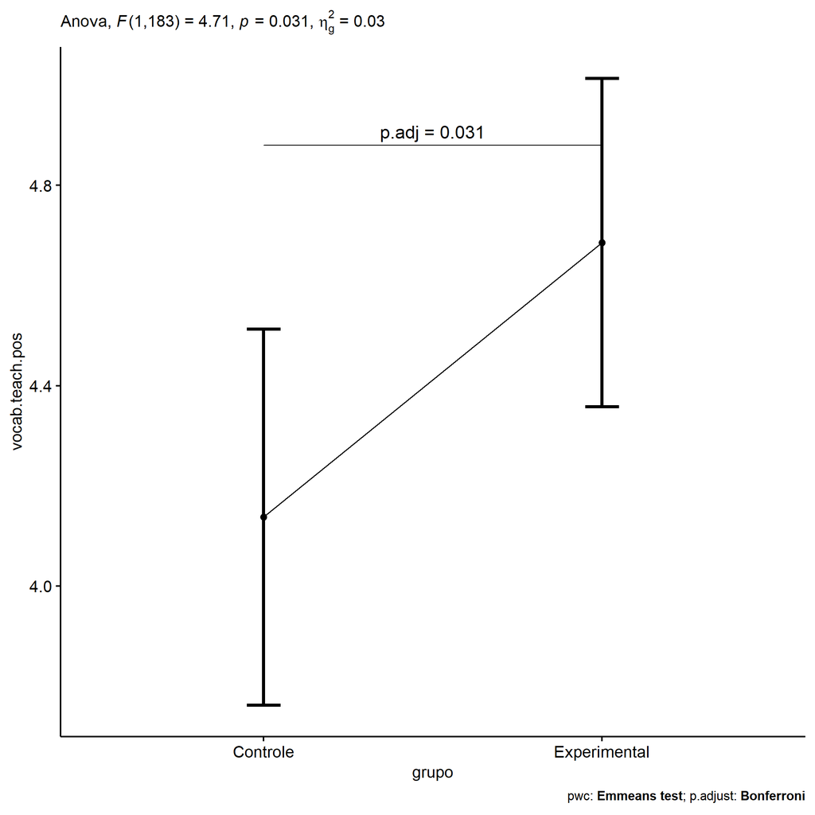

```r
if (!is.null(nrow(plots[["grupo"]]$data)))
  plots[["grupo"]] + ggplot2::scale_color_manual(values = color[["grupo"]])
```

```r
plots <- oneWayAncovaBoxPlots(
  wdat, "vocab.teach.pos", "grupo", aov, pwc, covar = "vocab.teach.pre",
  theme = "classic", color = color[["grupo"]],
  subtitle = which(aov$Effect == "grupo"))
```

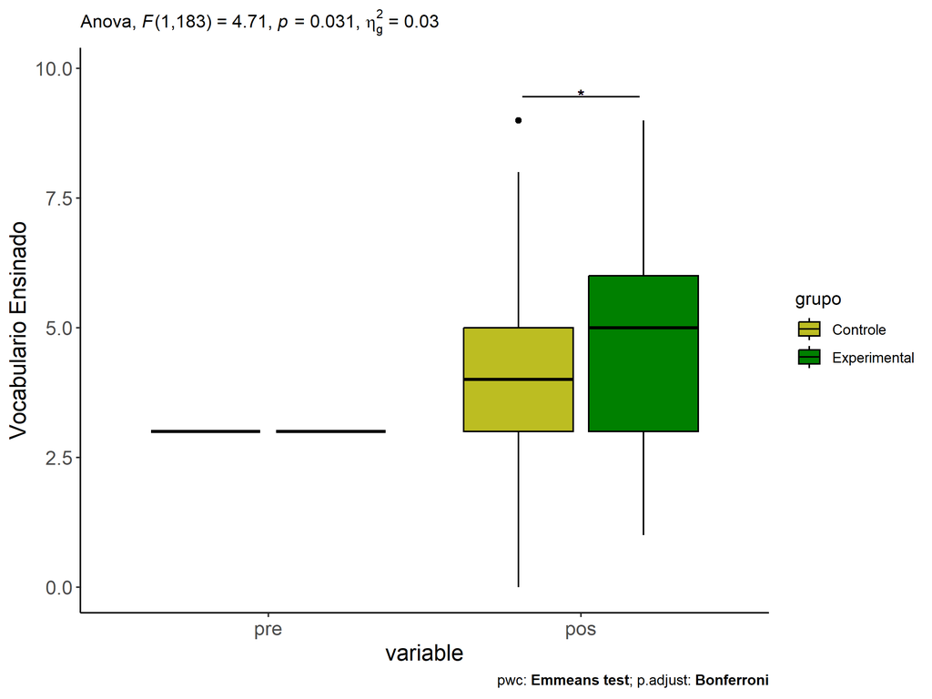

```r
if (length(unique(wdat[["grupo"]])) > 1)
  plots[["grupo"]] + ggplot2::ylab("Vocabulario Ensinado") + ggplot2::scale_x_discrete(labels=c('pre', 'pos'))
```

```r
if (length(unique(wdat.long[["grupo"]])) > 1)
  plots <- oneWayAncovaBoxPlots(
    wdat.long, "vocab.teach", "grupo", aov, pwc.long, pre.post = "time",
    theme = "classic", color = color$prepost)
```

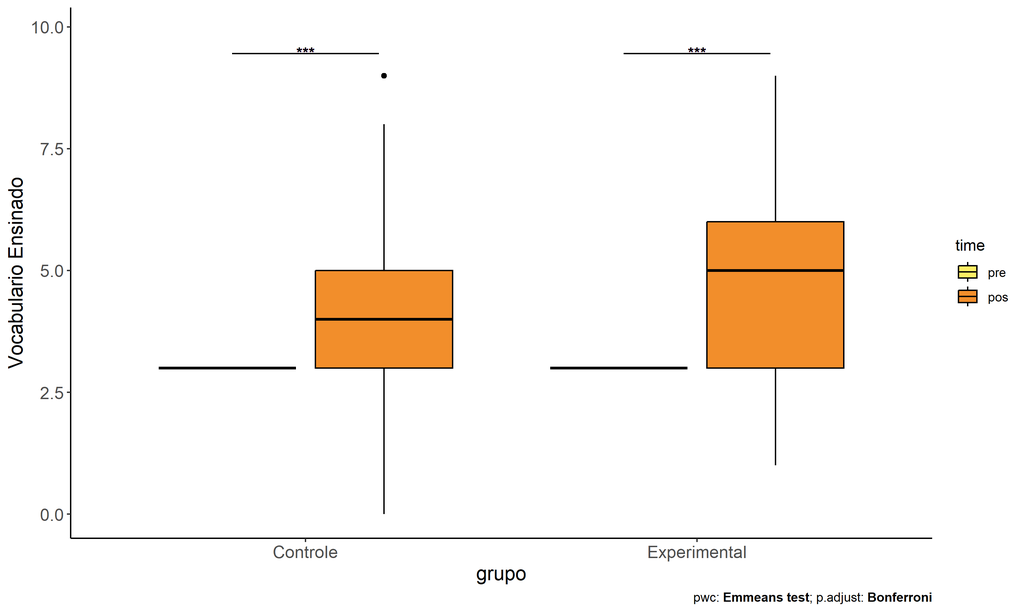

```r
if (length(unique(wdat.long[["grupo"]])) > 1)
  plots[["grupo"]] + ggplot2::ylab("Vocabulario Ensinado")
```

### Checking linearity assumption

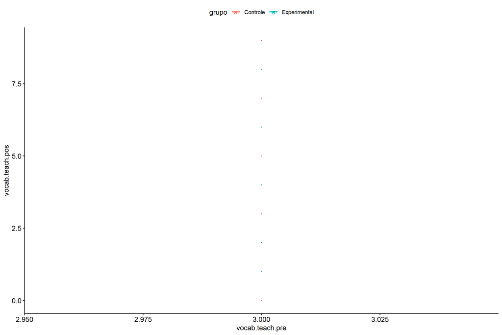

```r
ggscatter(wdat, x = "vocab.teach.pre", y = "vocab.teach.pos", size = 0.5,
          color = "grupo", add = "reg.line")+
  stat_regline_equation(
    aes(label =  paste(..eq.label.., ..rr.label.., sep = "~~~~"), color = grupo)
  )
```

### Checking normality and homogeneity

```r
res <- augment(lm(vocab.teach.pos ~ vocab.teach.pre + grupo, data = wdat))
```

```r
shapiro_test(res$.resid)
```

```
## # A tibble: 1 × 3
##   variable   statistic p.value
##   <chr>          <dbl>   <dbl>
## 1 res$.resid     0.986  0.0692
```

```r
levene_test(res, .resid ~ grupo)
```

```
## # A tibble: 1 × 4
##     df1   df2 statistic     p
##   <int> <int>     <dbl> <dbl>
## 1     1   183      1.03 0.312
```

# ANCOVA and Pairwise for two factors **grupo:Sexo**

## Without remove non-normal data

```r
pdat = remove_group_data(dat[!is.na(dat[["grupo"]]) & !is.na(dat[["Sexo"]]),], "vocab.teach.pos", c("grupo","Sexo"))

pdat.long <- rbind(pdat[,c("id","grupo","Sexo")], pdat[,c("id","grupo","Sexo")])
pdat.long[["time"]] <- c(rep("pre", nrow(pdat)), rep("pos", nrow(pdat)))
pdat.long[["time"]] <- factor(pdat.long[["time"]], c("pre","pos"))
pdat.long[["vocab.teach"]] <- c(pdat[["vocab.teach.pre"]], pdat[["vocab.teach.pos"]])

aov = anova_test(pdat, vocab.teach.pos ~ vocab.teach.pre + grupo*Sexo)
laov[["grupo:Sexo"]] <- get_anova_table(aov)
```

```r
pwcs <- list()
pwcs[["Sexo"]] <- emmeans_test(
  group_by(pdat, grupo), vocab.teach.pos ~ Sexo,
  covariate = vocab.teach.pre, p.adjust.method = "bonferroni")
pwcs[["grupo"]] <- emmeans_test(
  group_by(pdat, Sexo), vocab.teach.pos ~ grupo,
  covariate = vocab.teach.pre, p.adjust.method = "bonferroni")

pwc <- plyr::rbind.fill(pwcs[["grupo"]], pwcs[["Sexo"]])
pwc <- pwc[,c("grupo","Sexo", colnames(pwc)[!colnames(pwc) %in% c("grupo","Sexo")])]
```

```r
pwc.long <- emmeans_test(dplyr::group_by_at(pdat.long, c("grupo","Sexo")),
                         vocab.teach ~ time,
                         p.adjust.method = "bonferroni")
lpwc[["grupo:Sexo"]] <- plyr::rbind.fill(pwc, pwc.long)
```

```r
ds <- get.descriptives(pdat, "vocab.teach.pos", c("grupo","Sexo"), covar = "vocab.teach.pre")
ds <- merge(ds[ds$variable != "vocab.teach.pre",],
            ds[ds$variable == "vocab.teach.pre", !colnames(ds) %in% c("variable")],
            by = c("grupo","Sexo"), all.x = T, suffixes = c("", ".vocab.teach.pre"))
ds <- merge(get_emmeans(pwcs[["grupo"]]), ds, by = c("grupo","Sexo"), suffixes = c(".emms", ""))
ds <- ds[,c("grupo","Sexo","n","mean.vocab.teach.pre","se.vocab.teach.pre","mean","se","emmean","se.emms")]

colnames(ds) <- c("grupo","Sexo", "N", paste0(c("M","SE")," (pre)"),
                  paste0(c("M","SE"), " (unadj)"), paste0(c("M", "SE"), " (adj)"))

lemms[["grupo:Sexo"]] <- ds
```

## Computing ANCOVA and PairWise After removing non-normal data (OK)

```r
wdat = pdat

res = residuals(lm(vocab.teach.pos ~ vocab.teach.pre + grupo*Sexo, data = wdat))
non.normal = getNonNormal(res, wdat$id, plimit = 0.05)

wdat = wdat[!wdat$id %in% non.normal,]

wdat.long <- rbind(wdat[,c("id","grupo","Sexo")], wdat[,c("id","grupo","Sexo")])
wdat.long[["time"]] <- c(rep("pre", nrow(wdat)), rep("pos", nrow(wdat)))
wdat.long[["time"]] <- factor(wdat.long[["time"]], c("pre","pos"))
wdat.long[["vocab.teach"]] <- c(wdat[["vocab.teach.pre"]], wdat[["vocab.teach.pos"]])


ldat[["grupo:Sexo"]] = wdat

(non.normal)
```

```r
aov = anova_test(wdat, vocab.teach.pos ~ vocab.teach.pre + grupo*Sexo)
laov[["grupo:Sexo"]] <- merge(get_anova_table(aov), laov[["grupo:Sexo"]], by="Effect", suffixes = c("","'"))

(df = get_anova_table(aov))
```

```
## ANOVA Table (type II tests)
##
##            Effect DFn DFd     F     p p<.05   ges
## 1 vocab.teach.pre   0 181    NA    NA  <NA>    NA
## 2           grupo   1 181 4.645 0.032     * 0.025
## 3            Sexo   1 181 0.378 0.540       0.002
## 4      grupo:Sexo   1 181 1.206 0.274       0.007
```

| Effect | DFn | DFd | F | p | p<.05 | ges |
| --- | --- | --- | --- | --- | --- | --- |
| vocab.teach.pre | 0 | 181 |  |  |  |  |
| grupo | 1 | 181 | 4.645 | 0.032 | * | 0.025 |
| Sexo | 1 | 181 | 0.378 | 0.540 |  | 0.002 |
| grupo:Sexo | 1 | 181 | 1.206 | 0.274 |  | 0.007 |

```r
pwcs <- list()
pwcs[["Sexo"]] <- emmeans_test(
  group_by(wdat, grupo), vocab.teach.pos ~ Sexo,
  covariate = vocab.teach.pre, p.adjust.method = "bonferroni")
pwcs[["grupo"]] <- emmeans_test(
  group_by(wdat, Sexo), vocab.teach.pos ~ grupo,
  covariate = vocab.teach.pre, p.adjust.method = "bonferroni")

pwc <- plyr::rbind.fill(pwcs[["grupo"]], pwcs[["Sexo"]])
pwc <- pwc[,c("grupo","Sexo", colnames(pwc)[!colnames(pwc) %in% c("grupo","Sexo")])]
```

| grupo | Sexo | term | .y. | group1 | group2 | df | statistic | p | p.adj | p.adj.signif |
| --- | --- | --- | --- | --- | --- | --- | --- | --- | --- | --- |
|  | F | vocab.teach.pre*grupo | vocab.teach.pos | Controle | Experimental | 181 | -2.288 | 0.023 | 0.023 | * |
|  | M | vocab.teach.pre*grupo | vocab.teach.pos | Controle | Experimental | 181 | -0.785 | 0.434 | 0.434 | ns |
| Controle |  | vocab.teach.pre*Sexo | vocab.teach.pos | F | M | 181 | -0.424 | 0.672 | 0.672 | ns |
| Experimental |  | vocab.teach.pre*Sexo | vocab.teach.pos | F | M | 181 | 1.185 | 0.238 | 0.238 | ns |

```r
pwc.long <- emmeans_test(dplyr::group_by_at(wdat.long, c("grupo","Sexo")),
                         vocab.teach ~ time,
                         p.adjust.method = "bonferroni")
lpwc[["grupo:Sexo"]] <- merge(plyr::rbind.fill(pwc, pwc.long), lpwc[["grupo:Sexo"]], by=c("grupo","Sexo","term",".y.","group1","group2"), suffixes = c("","'"))
```

| grupo | Sexo | term | .y. | group1 | group2 | df | statistic | p | p.adj | p.adj.signif |
| --- | --- | --- | --- | --- | --- | --- | --- | --- | --- | --- |
| Controle | F | time | vocab.teach | pre | pos | 362 | -3.808 | 0 | 0 | *** |
| Controle | M | time | vocab.teach | pre | pos | 362 | -4.618 | 0 | 0 | **** |
| Experimental | F | time | vocab.teach | pre | pos | 362 | -7.976 | 0 | 0 | **** |
| Experimental | M | time | vocab.teach | pre | pos | 362 | -6.368 | 0 | 0 | **** |

```r
ds <- get.descriptives(wdat, "vocab.teach.pos", c("grupo","Sexo"), covar = "vocab.teach.pre")
ds <- merge(ds[ds$variable != "vocab.teach.pre",],
            ds[ds$variable == "vocab.teach.pre", !colnames(ds) %in% c("variable")],
            by = c("grupo","Sexo"), all.x = T, suffixes = c("", ".vocab.teach.pre"))
ds <- merge(get_emmeans(pwcs[["grupo"]]), ds, by = c("grupo","Sexo"), suffixes = c(".emms", ""))
ds <- ds[,c("grupo","Sexo","n","mean.vocab.teach.pre","se.vocab.teach.pre","mean","se","emmean","se.emms")]

colnames(ds) <- c("grupo","Sexo", "N", paste0(c("M","SE")," (pre)"),
                  paste0(c("M","SE"), " (unadj)"), paste0(c("M", "SE"), " (adj)"))

lemms[["grupo:Sexo"]] <- merge(ds, lemms[["grupo:Sexo"]], by=c("grupo","Sexo"), suffixes = c("","'"))
```

| grupo | Sexo | N | M (pre) | SE (pre) | M (unadj) | SE (unadj) | M (adj) | SE (adj) |
| --- | --- | --- | --- | --- | --- | --- | --- | --- |
| Controle | F | 38 | 3 | 0 | 4.053 | 0.256 | 4.053 | 0.276 |
| Controle | M | 42 | 3 | 0 | 4.214 | 0.274 | 4.214 | 0.263 |
| Experimental | F | 52 | 3 | 0 | 4.885 | 0.242 | 4.885 | 0.236 |
| Experimental | M | 53 | 3 | 0 | 4.491 | 0.233 | 4.491 | 0.234 |

### Plots for ancova

```r
plots <- twoWayAncovaPlots(
  wdat, "vocab.teach.pos", c("grupo","Sexo"), aov, pwcs, addParam = c("mean_se"),
  font.label.size=10, step.increase=0.05, p.label="p.adj",
  subtitle = which(aov$Effect == "grupo:Sexo"))
```

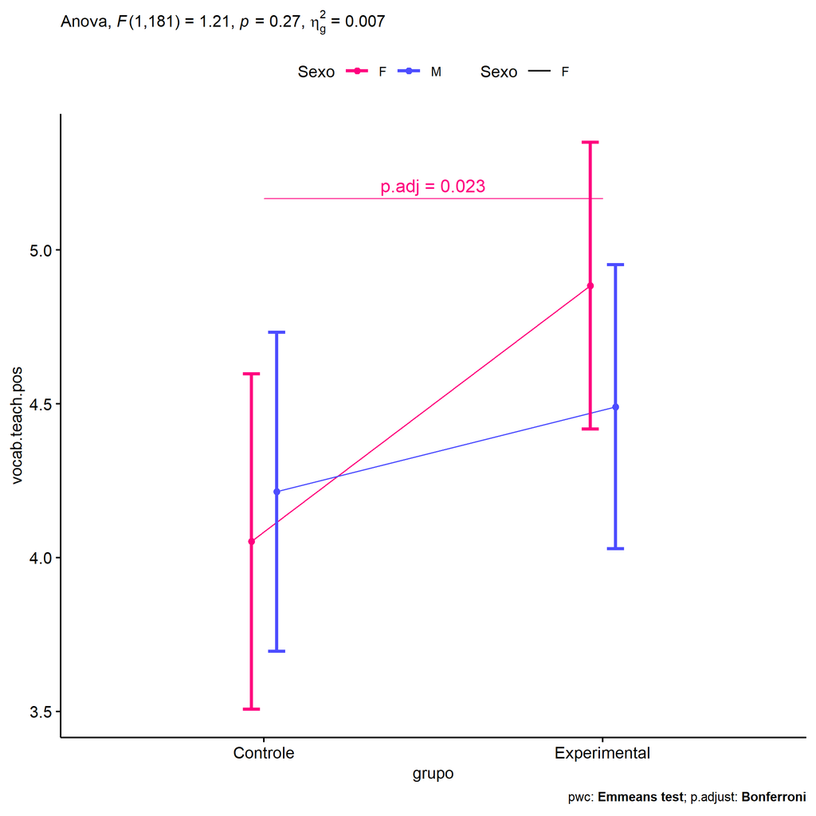

```r
if (!is.null(plots[["grupo"]]))
  plots[["grupo"]] + ggplot2::scale_color_manual(values = color[["Sexo"]])
```

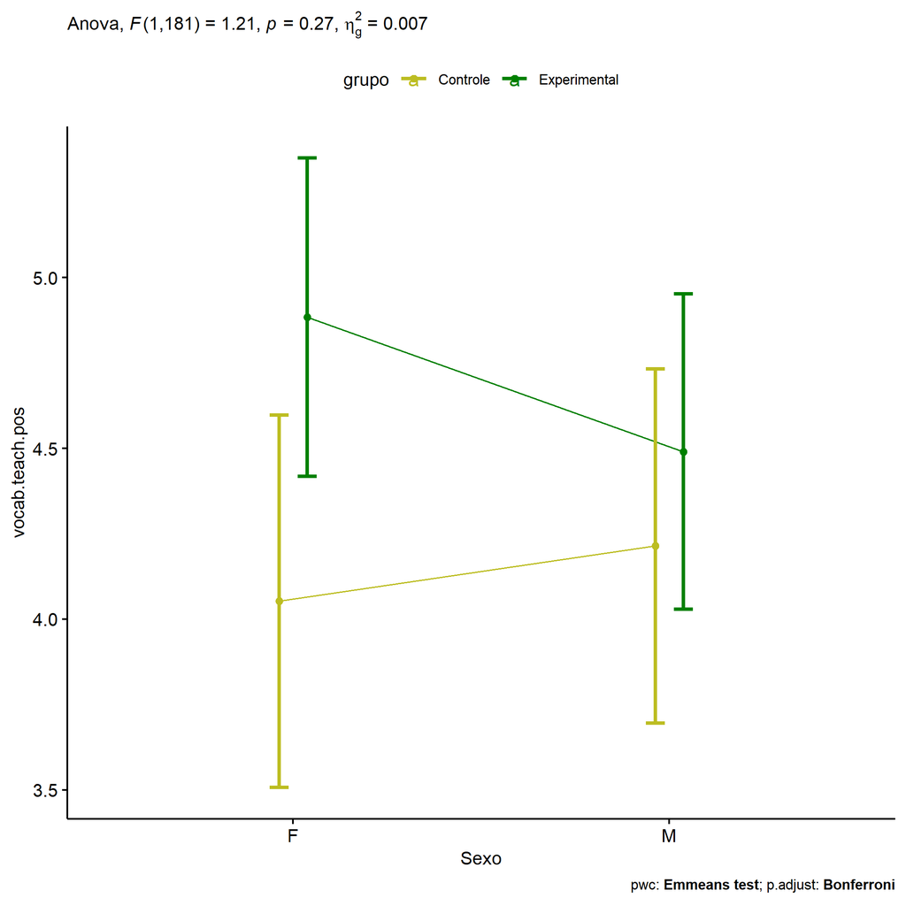

```r
if (!is.null(plots[["Sexo"]]))
  plots[["Sexo"]] + ggplot2::scale_color_manual(values = color[["grupo"]])
```

```r
plots <- twoWayAncovaBoxPlots(
  wdat, "vocab.teach.pos", c("grupo","Sexo"), aov, pwcs, covar = "vocab.teach.pre",
  theme = "classic", color = color[["grupo:Sexo"]],
  subtitle = which(aov$Effect == "grupo:Sexo"))
```

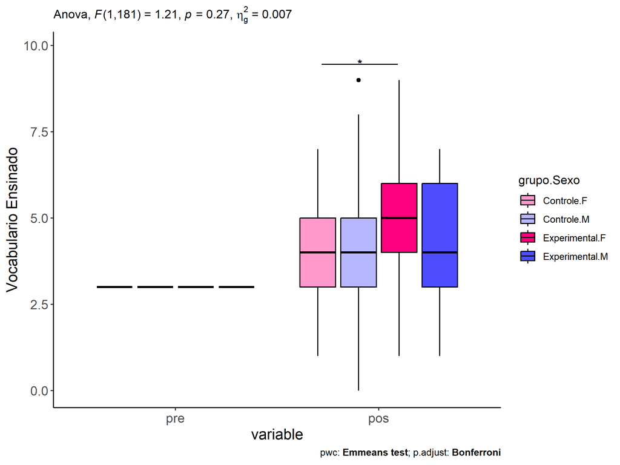

```r
plots[["grupo:Sexo"]] + ggplot2::ylab("Vocabulario Ensinado") + ggplot2::scale_x_discrete(labels=c('pre', 'pos'))
```

```r
plots <- twoWayAncovaBoxPlots(
  wdat.long, "vocab.teach", c("grupo","Sexo"), aov, pwc.long, pre.post = "time",
  theme = "classic", color = color$prepost)
```

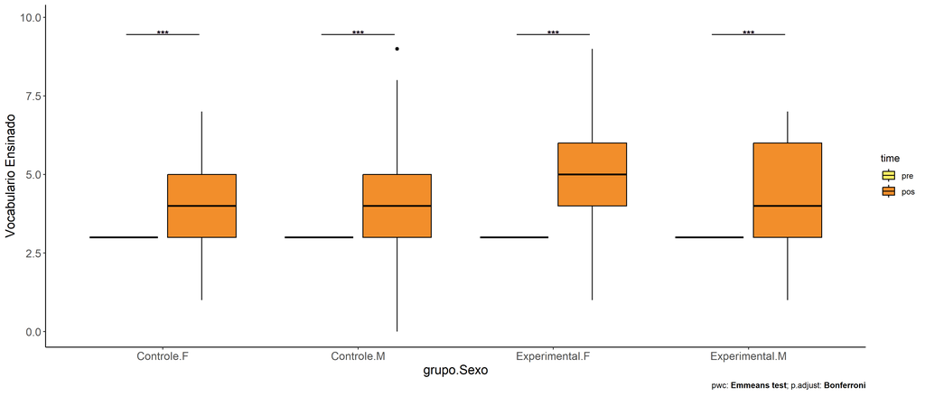

```r
plots[["grupo:Sexo"]] + ggplot2::ylab("Vocabulario Ensinado")
```

### Checking linearity assumption

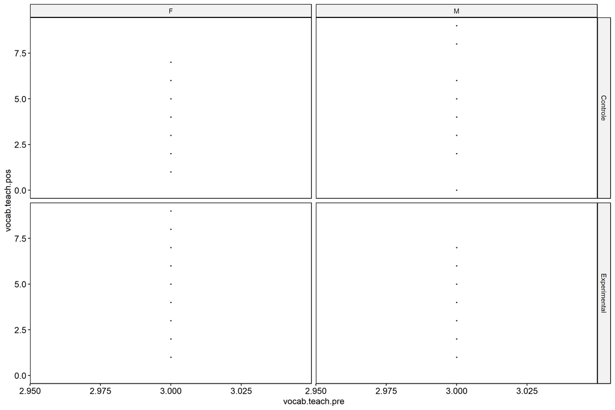

```r
ggscatter(wdat, x = "vocab.teach.pre", y = "vocab.teach.pos", size = 0.5,
          facet.by = c("grupo","Sexo"), add = "reg.line")+
  stat_regline_equation(
    aes(label =  paste(..eq.label.., ..rr.label.., sep = "~~~~"))
  )
```

### Checking normality and homogeneity

```r
res <- augment(lm(vocab.teach.pos ~ vocab.teach.pre + grupo*Sexo, data = wdat))
```

```r
shapiro_test(res$.resid)
```

```
## # A tibble: 1 × 3
##   variable   statistic p.value
##   <chr>          <dbl>   <dbl>
## 1 res$.resid     0.991   0.269
```

```r
levene_test(res, .resid ~ grupo*Sexo)
```

```
## # A tibble: 1 × 4
##     df1   df2 statistic     p
##   <int> <int>     <dbl> <dbl>
## 1     3   181     0.255 0.858
```

# ANCOVA and Pairwise for two factors **grupo:Zona**

## Without remove non-normal data

```r
pdat = remove_group_data(dat[!is.na(dat[["grupo"]]) & !is.na(dat[["Zona"]]),], "vocab.teach.pos", c("grupo","Zona"))

pdat.long <- rbind(pdat[,c("id","grupo","Zona")], pdat[,c("id","grupo","Zona")])
pdat.long[["time"]] <- c(rep("pre", nrow(pdat)), rep("pos", nrow(pdat)))
pdat.long[["time"]] <- factor(pdat.long[["time"]], c("pre","pos"))
pdat.long[["vocab.teach"]] <- c(pdat[["vocab.teach.pre"]], pdat[["vocab.teach.pos"]])

aov = anova_test(pdat, vocab.teach.pos ~ vocab.teach.pre + grupo*Zona)
laov[["grupo:Zona"]] <- get_anova_table(aov)
```

```r
pwcs <- list()
pwcs[["Zona"]] <- emmeans_test(
  group_by(pdat, grupo), vocab.teach.pos ~ Zona,
  covariate = vocab.teach.pre, p.adjust.method = "bonferroni")
pwcs[["grupo"]] <- emmeans_test(
  group_by(pdat, Zona), vocab.teach.pos ~ grupo,
  covariate = vocab.teach.pre, p.adjust.method = "bonferroni")

pwc <- plyr::rbind.fill(pwcs[["grupo"]], pwcs[["Zona"]])
pwc <- pwc[,c("grupo","Zona", colnames(pwc)[!colnames(pwc) %in% c("grupo","Zona")])]
```

```r
pwc.long <- emmeans_test(dplyr::group_by_at(pdat.long, c("grupo","Zona")),
                         vocab.teach ~ time,
                         p.adjust.method = "bonferroni")
lpwc[["grupo:Zona"]] <- plyr::rbind.fill(pwc, pwc.long)
```

```r
ds <- get.descriptives(pdat, "vocab.teach.pos", c("grupo","Zona"), covar = "vocab.teach.pre")
ds <- merge(ds[ds$variable != "vocab.teach.pre",],
            ds[ds$variable == "vocab.teach.pre", !colnames(ds) %in% c("variable")],
            by = c("grupo","Zona"), all.x = T, suffixes = c("", ".vocab.teach.pre"))
ds <- merge(get_emmeans(pwcs[["grupo"]]), ds, by = c("grupo","Zona"), suffixes = c(".emms", ""))
ds <- ds[,c("grupo","Zona","n","mean.vocab.teach.pre","se.vocab.teach.pre","mean","se","emmean","se.emms")]

colnames(ds) <- c("grupo","Zona", "N", paste0(c("M","SE")," (pre)"),
                  paste0(c("M","SE"), " (unadj)"), paste0(c("M", "SE"), " (adj)"))

lemms[["grupo:Zona"]] <- ds
```

## Computing ANCOVA and PairWise After removing non-normal data (OK)

```r
wdat = pdat

res = residuals(lm(vocab.teach.pos ~ vocab.teach.pre + grupo*Zona, data = wdat))
non.normal = getNonNormal(res, wdat$id, plimit = 0.05)

wdat = wdat[!wdat$id %in% non.normal,]

wdat.long <- rbind(wdat[,c("id","grupo","Zona")], wdat[,c("id","grupo","Zona")])
wdat.long[["time"]] <- c(rep("pre", nrow(wdat)), rep("pos", nrow(wdat)))
wdat.long[["time"]] <- factor(wdat.long[["time"]], c("pre","pos"))
wdat.long[["vocab.teach"]] <- c(wdat[["vocab.teach.pre"]], wdat[["vocab.teach.pos"]])


ldat[["grupo:Zona"]] = wdat

(non.normal)
```

```r
aov = anova_test(wdat, vocab.teach.pos ~ vocab.teach.pre + grupo*Zona)
laov[["grupo:Zona"]] <- merge(get_anova_table(aov), laov[["grupo:Zona"]], by="Effect", suffixes = c("","'"))

(df = get_anova_table(aov))
```

```
## ANOVA Table (type II tests)
##
##            Effect DFn DFd     F     p p<.05   ges
## 1 vocab.teach.pre   0 124    NA    NA  <NA>    NA
## 2           grupo   1 124 2.893 0.091       0.023
## 3            Zona   1 124 1.411 0.237       0.011
## 4      grupo:Zona   1 124 0.244 0.622       0.002
```

| Effect | DFn | DFd | F | p | p<.05 | ges |
| --- | --- | --- | --- | --- | --- | --- |
| vocab.teach.pre | 0 | 124 |  |  |  |  |
| grupo | 1 | 124 | 2.893 | 0.091 |  | 0.023 |
| Zona | 1 | 124 | 1.411 | 0.237 |  | 0.011 |
| grupo:Zona | 1 | 124 | 0.244 | 0.622 |  | 0.002 |

```r
pwcs <- list()
pwcs[["Zona"]] <- emmeans_test(
  group_by(wdat, grupo), vocab.teach.pos ~ Zona,
  covariate = vocab.teach.pre, p.adjust.method = "bonferroni")
pwcs[["grupo"]] <- emmeans_test(
  group_by(wdat, Zona), vocab.teach.pos ~ grupo,
  covariate = vocab.teach.pre, p.adjust.method = "bonferroni")

pwc <- plyr::rbind.fill(pwcs[["grupo"]], pwcs[["Zona"]])
pwc <- pwc[,c("grupo","Zona", colnames(pwc)[!colnames(pwc) %in% c("grupo","Zona")])]
```

| grupo | Zona | term | .y. | group1 | group2 | df | statistic | p | p.adj | p.adj.signif |
| --- | --- | --- | --- | --- | --- | --- | --- | --- | --- | --- |
|  | Rural | vocab.teach.pre*grupo | vocab.teach.pos | Controle | Experimental | 124 | -1.665 | 0.099 | 0.099 | ns |
|  | Urbana | vocab.teach.pre*grupo | vocab.teach.pos | Controle | Experimental | 124 | -0.605 | 0.546 | 0.546 | ns |
| Controle |  | vocab.teach.pre*Zona | vocab.teach.pos | Rural | Urbana | 124 | -1.154 | 0.251 | 0.251 | ns |
| Experimental |  | vocab.teach.pre*Zona | vocab.teach.pos | Rural | Urbana | 124 | -0.569 | 0.570 | 0.570 | ns |

```r
pwc.long <- emmeans_test(dplyr::group_by_at(wdat.long, c("grupo","Zona")),
                         vocab.teach ~ time,
                         p.adjust.method = "bonferroni")
lpwc[["grupo:Zona"]] <- merge(plyr::rbind.fill(pwc, pwc.long), lpwc[["grupo:Zona"]], by=c("grupo","Zona","term",".y.","group1","group2"), suffixes = c("","'"))
```

| grupo | Zona | term | .y. | group1 | group2 | df | statistic | p | p.adj | p.adj.signif |
| --- | --- | --- | --- | --- | --- | --- | --- | --- | --- | --- |
| Controle | Rural | time | vocab.teach | pre | pos | 248 | -3.423 | 0.001 | 0.001 | *** |
| Controle | Urbana | time | vocab.teach | pre | pos | 248 | -3.620 | 0.000 | 0.000 | *** |
| Experimental | Rural | time | vocab.teach | pre | pos | 248 | -5.667 | 0.000 | 0.000 | **** |
| Experimental | Urbana | time | vocab.teach | pre | pos | 248 | -5.483 | 0.000 | 0.000 | **** |

```r
ds <- get.descriptives(wdat, "vocab.teach.pos", c("grupo","Zona"), covar = "vocab.teach.pre")
ds <- merge(ds[ds$variable != "vocab.teach.pre",],
            ds[ds$variable == "vocab.teach.pre", !colnames(ds) %in% c("variable")],
            by = c("grupo","Zona"), all.x = T, suffixes = c("", ".vocab.teach.pre"))
ds <- merge(get_emmeans(pwcs[["grupo"]]), ds, by = c("grupo","Zona"), suffixes = c(".emms", ""))
ds <- ds[,c("grupo","Zona","n","mean.vocab.teach.pre","se.vocab.teach.pre","mean","se","emmean","se.emms")]

colnames(ds) <- c("grupo","Zona", "N", paste0(c("M","SE")," (pre)"),
                  paste0(c("M","SE"), " (unadj)"), paste0(c("M", "SE"), " (adj)"))

lemms[["grupo:Zona"]] <- merge(ds, lemms[["grupo:Zona"]], by=c("grupo","Zona"), suffixes = c("","'"))
```

| grupo | Zona | N | M (pre) | SE (pre) | M (unadj) | SE (unadj) | M (adj) | SE (adj) |
| --- | --- | --- | --- | --- | --- | --- | --- | --- |
| Controle | Rural | 42 | 3 | 0 | 3.929 | 0.271 | 3.929 | 0.271 |
| Controle | Urbana | 18 | 3 | 0 | 4.500 | 0.336 | 4.500 | 0.414 |
| Experimental | Rural | 40 | 3 | 0 | 4.575 | 0.304 | 4.575 | 0.278 |
| Experimental | Urbana | 28 | 3 | 0 | 4.821 | 0.321 | 4.821 | 0.332 |

### Plots for ancova

```r
plots <- twoWayAncovaPlots(
  wdat, "vocab.teach.pos", c("grupo","Zona"), aov, pwcs, addParam = c("mean_se"),
  font.label.size=10, step.increase=0.05, p.label="p.adj",
  subtitle = which(aov$Effect == "grupo:Zona"))
```

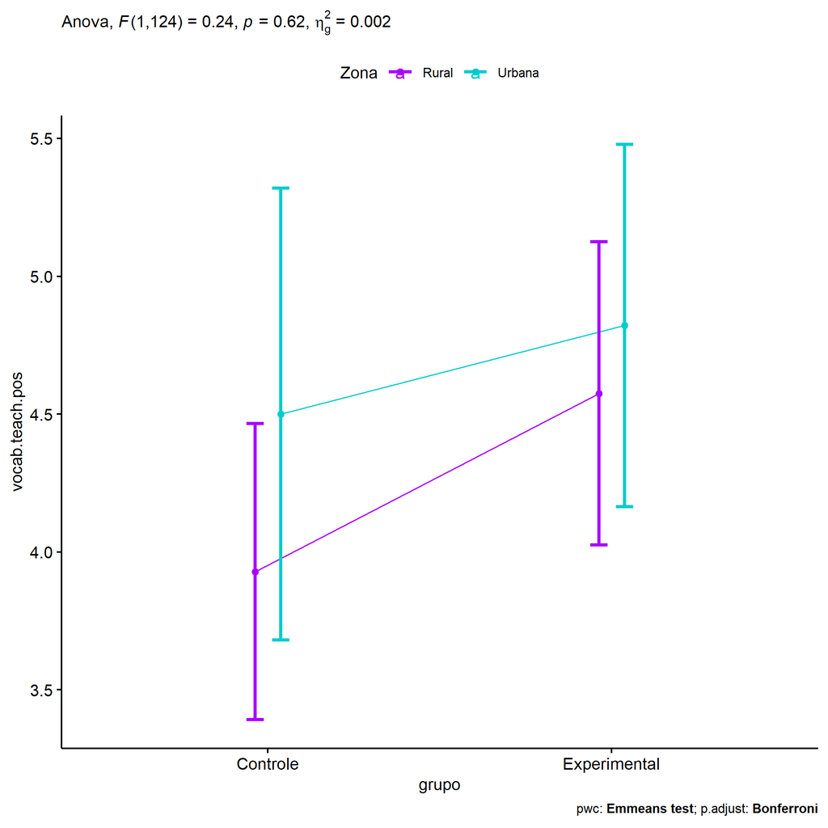

```r
if (!is.null(plots[["grupo"]]))
  plots[["grupo"]] + ggplot2::scale_color_manual(values = color[["Zona"]])
```

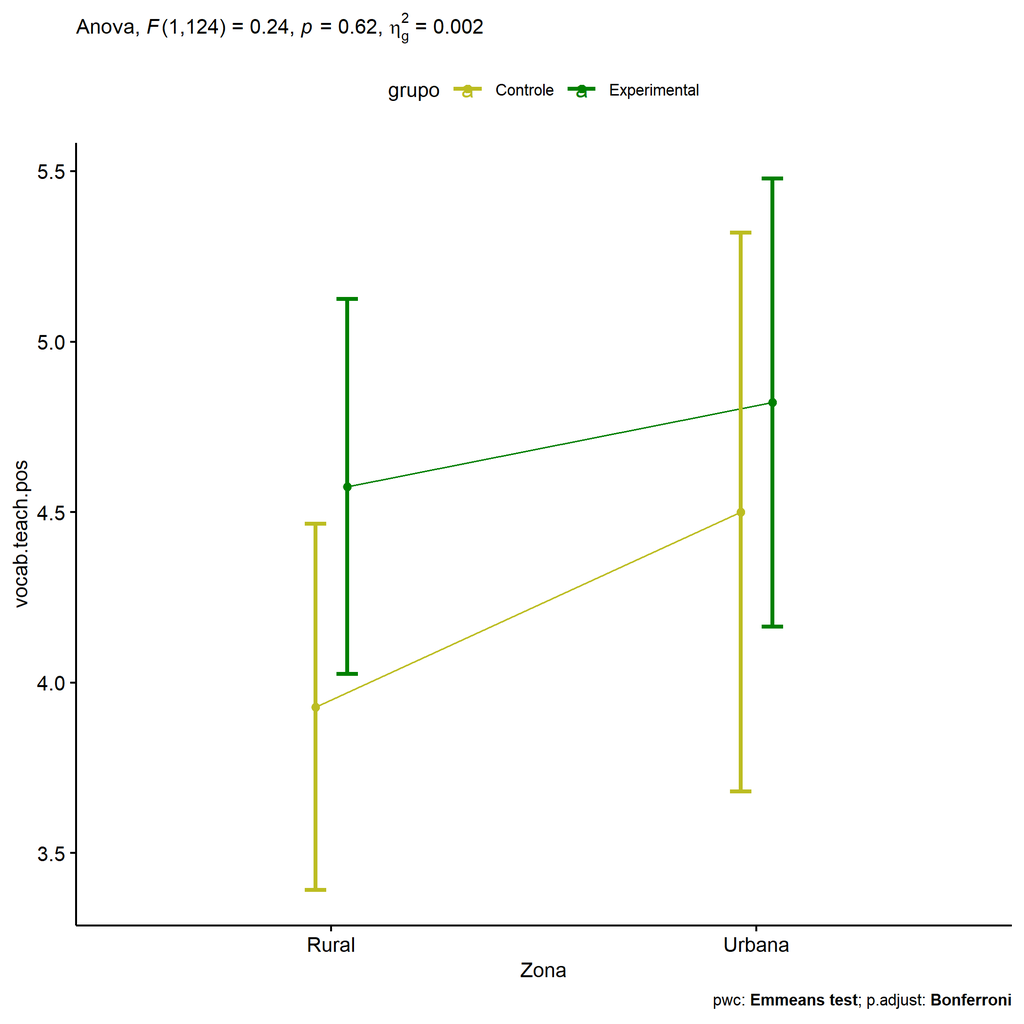

```r
if (!is.null(plots[["Zona"]]))
  plots[["Zona"]] + ggplot2::scale_color_manual(values = color[["grupo"]])
```

```r
plots <- twoWayAncovaBoxPlots(
  wdat, "vocab.teach.pos", c("grupo","Zona"), aov, pwcs, covar = "vocab.teach.pre",
  theme = "classic", color = color[["grupo:Zona"]],
  subtitle = which(aov$Effect == "grupo:Zona"))
```

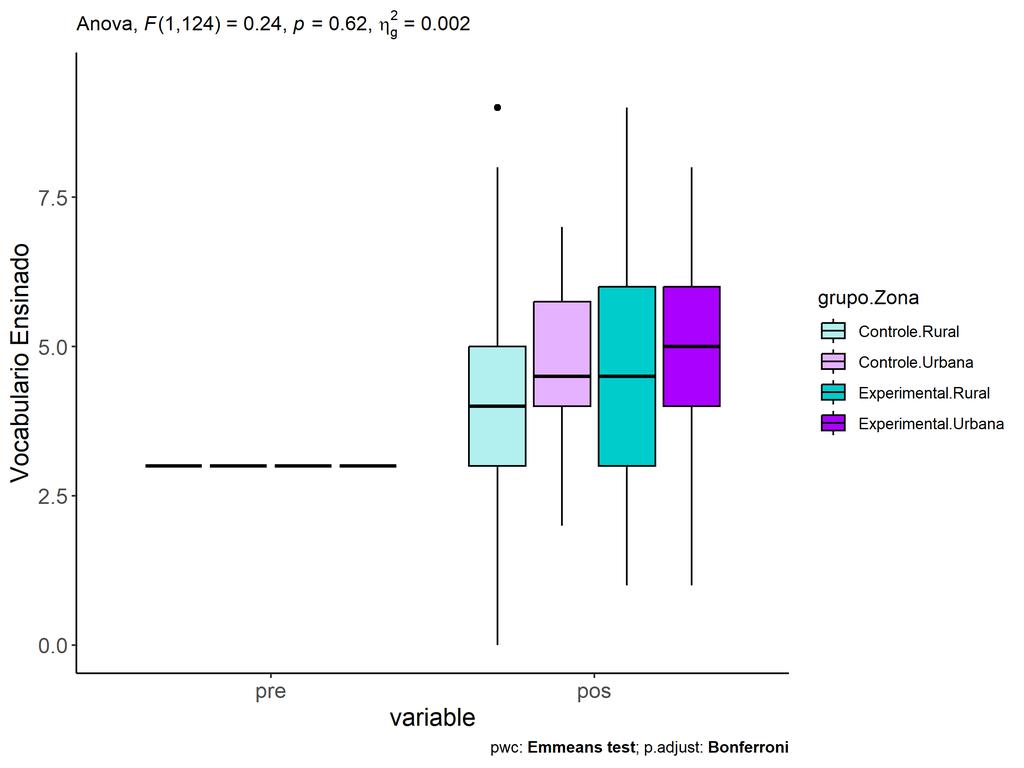

```r
plots[["grupo:Zona"]] + ggplot2::ylab("Vocabulario Ensinado") + ggplot2::scale_x_discrete(labels=c('pre', 'pos'))
```

```r
plots <- twoWayAncovaBoxPlots(
  wdat.long, "vocab.teach", c("grupo","Zona"), aov, pwc.long, pre.post = "time",
  theme = "classic", color = color$prepost)
```

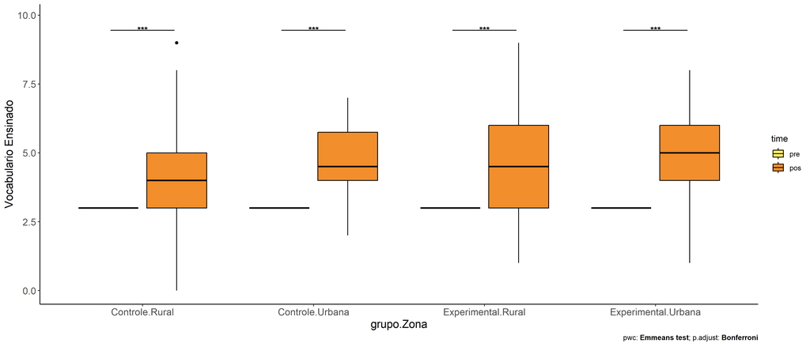

```r
plots[["grupo:Zona"]] + ggplot2::ylab("Vocabulario Ensinado")
```

### Checking linearity assumption

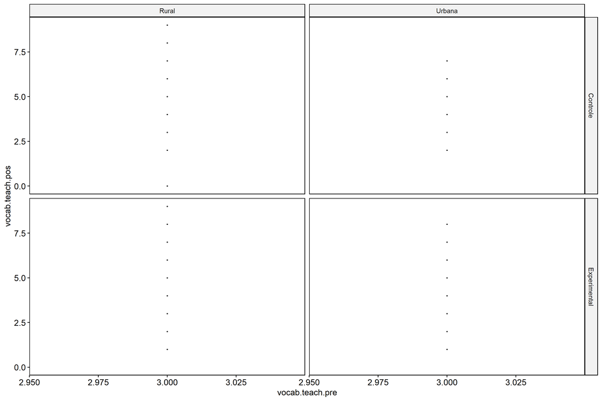

```r
ggscatter(wdat, x = "vocab.teach.pre", y = "vocab.teach.pos", size = 0.5,
          facet.by = c("grupo","Zona"), add = "reg.line")+
  stat_regline_equation(
    aes(label =  paste(..eq.label.., ..rr.label.., sep = "~~~~"))
  )
```

### Checking normality and homogeneity

```r
res <- augment(lm(vocab.teach.pos ~ vocab.teach.pre + grupo*Zona, data = wdat))
```

```r
shapiro_test(res$.resid)
```

```
## # A tibble: 1 × 3
##   variable   statistic p.value
##   <chr>          <dbl>   <dbl>
## 1 res$.resid     0.986   0.203
```

```r
levene_test(res, .resid ~ grupo*Zona)
```

```
## # A tibble: 1 × 4
##     df1   df2 statistic     p
##   <int> <int>     <dbl> <dbl>
## 1     3   124     0.846 0.471
```

# ANCOVA and Pairwise for two factors **grupo:Cor.Raca**

## Without remove non-normal data

```r
pdat = remove_group_data(dat[!is.na(dat[["grupo"]]) & !is.na(dat[["Cor.Raca"]]),], "vocab.teach.pos", c("grupo","Cor.Raca"))
pdat.long <- rbind(pdat[,c("id","grupo","Cor.Raca")], pdat[,c("id","grupo","Cor.Raca")])
pdat.long[["time"]] <- c(rep("pre", nrow(pdat)), rep("pos", nrow(pdat)))
pdat.long[["time"]] <- factor(pdat.long[["time"]], c("pre","pos"))
pdat.long[["vocab.teach"]] <- c(pdat[["vocab.teach.pre"]], pdat[["vocab.teach.pos"]])

aov = anova_test(pdat, vocab.teach.pos ~ vocab.teach.pre + grupo*Cor.Raca)
laov[["grupo:Cor.Raca"]] <- get_anova_table(aov)
```

```r
pwcs <- list()
pwcs[["Cor.Raca"]] <- emmeans_test(
  group_by(pdat, grupo), vocab.teach.pos ~ Cor.Raca,
  covariate = vocab.teach.pre, p.adjust.method = "bonferroni")
pwcs[["grupo"]] <- emmeans_test(
  group_by(pdat, Cor.Raca), vocab.teach.pos ~ grupo,
  covariate = vocab.teach.pre, p.adjust.method = "bonferroni")

pwc <- plyr::rbind.fill(pwcs[["grupo"]], pwcs[["Cor.Raca"]])
pwc <- pwc[,c("grupo","Cor.Raca", colnames(pwc)[!colnames(pwc) %in% c("grupo","Cor.Raca")])]
```

```r
pwc.long <- emmeans_test(dplyr::group_by_at(pdat.long, c("grupo","Cor.Raca")),
                         vocab.teach ~ time,
                         p.adjust.method = "bonferroni")
lpwc[["grupo:Cor.Raca"]] <- plyr::rbind.fill(pwc, pwc.long)
```

```r
ds <- get.descriptives(pdat, "vocab.teach.pos", c("grupo","Cor.Raca"), covar = "vocab.teach.pre")
ds <- merge(ds[ds$variable != "vocab.teach.pre",],
            ds[ds$variable == "vocab.teach.pre", !colnames(ds) %in% c("variable")],
            by = c("grupo","Cor.Raca"), all.x = T, suffixes = c("", ".vocab.teach.pre"))
ds <- merge(get_emmeans(pwcs[["grupo"]]), ds, by = c("grupo","Cor.Raca"), suffixes = c(".emms", ""))
ds <- ds[,c("grupo","Cor.Raca","n","mean.vocab.teach.pre","se.vocab.teach.pre","mean","se","emmean","se.emms")]

colnames(ds) <- c("grupo","Cor.Raca", "N", paste0(c("M","SE")," (pre)"),
                  paste0(c("M","SE"), " (unadj)"), paste0(c("M", "SE"), " (adj)"))

lemms[["grupo:Cor.Raca"]] <- ds
```

## Computing ANCOVA and PairWise After removing non-normal data (OK)

```r
wdat = pdat

res = residuals(lm(vocab.teach.pos ~ vocab.teach.pre + grupo*Cor.Raca, data = wdat))
non.normal = getNonNormal(res, wdat$id, plimit = 0.05)

wdat = wdat[!wdat$id %in% non.normal,]

wdat.long <- rbind(wdat[,c("id","grupo","Cor.Raca")], wdat[,c("id","grupo","Cor.Raca")])
wdat.long[["time"]] <- c(rep("pre", nrow(wdat)), rep("pos", nrow(wdat)))
wdat.long[["time"]] <- factor(wdat.long[["time"]], c("pre","pos"))
wdat.long[["vocab.teach"]] <- c(wdat[["vocab.teach.pre"]], wdat[["vocab.teach.pos"]])


ldat[["grupo:Cor.Raca"]] = wdat

(non.normal)
```

```
##  [1] "P3580" "P580"  "P1975" "P3670" "P822"  "P3548" "P3111" "P3236" "P975"  "P3556" "P3588" "P1023" "P2904"
## [14] "P572"  "P3106" "P511"  "P3477" "P534"  "P937"  "P538"  "P598"  "P462"  "P2941" "P573"  "P1158" "P1907"
## [27] "P2982" "P3561" "P3529" "P1719" "P3475" "P1071" "P3102" "P949"  "P1666"
```

```r
aov = anova_test(wdat, vocab.teach.pos ~ vocab.teach.pre + grupo*Cor.Raca)
laov[["grupo:Cor.Raca"]] <- merge(get_anova_table(aov), laov[["grupo:Cor.Raca"]], by="Effect", suffixes = c("","'"))

(df = get_anova_table(aov))
```

```
## ANOVA Table (type II tests)
##
##            Effect DFn DFd     F     p p<.05   ges
## 1 vocab.teach.pre   0  42    NA    NA  <NA>    NA
## 2           grupo   1  42 4.201 0.047     * 0.091
## 3        Cor.Raca   1  42 0.173 0.680       0.004
## 4  grupo:Cor.Raca   0  42    NA    NA  <NA>    NA
```

| Effect | DFn | DFd | F | p | p<.05 | ges |
| --- | --- | --- | --- | --- | --- | --- |
| vocab.teach.pre | 0 | 42 |  |  |  |  |
| grupo | 1 | 42 | 4.201 | 0.047 | * | 0.091 |
| Cor.Raca | 1 | 42 | 0.173 | 0.680 |  | 0.004 |
| grupo:Cor.Raca | 0 | 42 |  |  |  |  |

```r
pwcs <- list()
pwcs[["Cor.Raca"]] <- emmeans_test(
  group_by(wdat, grupo), vocab.teach.pos ~ Cor.Raca,
  covariate = vocab.teach.pre, p.adjust.method = "bonferroni")
pwcs[["grupo"]] <- emmeans_test(
  group_by(wdat, Cor.Raca), vocab.teach.pos ~ grupo,
  covariate = vocab.teach.pre, p.adjust.method = "bonferroni")

pwc <- plyr::rbind.fill(pwcs[["grupo"]], pwcs[["Cor.Raca"]])
pwc <- pwc[,c("grupo","Cor.Raca", colnames(pwc)[!colnames(pwc) %in% c("grupo","Cor.Raca")])]
```

| grupo | Cor.Raca | term | .y. | group1 | group2 | df | statistic | p | p.adj | p.adj.signif |
| --- | --- | --- | --- | --- | --- | --- | --- | --- | --- | --- |
|  | Branca | vocab.teach.pre*grupo | vocab.teach.pos | Controle | Experimental |  |  |  |  |  |
|  | Parda | vocab.teach.pre*grupo | vocab.teach.pos | Controle | Experimental | 42 | -2.050 | 0.047 | 0.047 | * |
| Controle |  | vocab.teach.pre*Cor.Raca | vocab.teach.pos | Branca | Parda | 42 | 0.416 | 0.680 | 0.680 | ns |
| Experimental |  | vocab.teach.pre*Cor.Raca | vocab.teach.pos | Branca | Parda |  |  |  |  |  |

```r
pwc.long <- emmeans_test(dplyr::group_by_at(wdat.long, c("grupo","Cor.Raca")),
                         vocab.teach ~ time,
                         p.adjust.method = "bonferroni")
lpwc[["grupo:Cor.Raca"]] <- merge(plyr::rbind.fill(pwc, pwc.long), lpwc[["grupo:Cor.Raca"]], by=c("grupo","Cor.Raca","term",".y.","group1","group2"), suffixes = c("","'"))
```

| grupo | Cor.Raca | term | .y. | group1 | group2 | df | statistic | p | p.adj | p.adj.signif |
| --- | --- | --- | --- | --- | --- | --- | --- | --- | --- | --- |
| Controle | Branca | time | vocab.teach | pre | pos | 84 | -2.877 | 0.005 | 0.005 | ** |
| Controle | Parda | time | vocab.teach | pre | pos | 84 | -3.966 | 0.000 | 0.000 | *** |
| Experimental | Branca | time | vocab.teach | pre | pos |  |  |  |  |  |
| Experimental | Parda | time | vocab.teach | pre | pos | 84 | -10.507 | 0.000 | 0.000 | **** |

```r
ds <- get.descriptives(wdat, "vocab.teach.pos", c("grupo","Cor.Raca"), covar = "vocab.teach.pre")
ds <- merge(ds[ds$variable != "vocab.teach.pre",],
            ds[ds$variable == "vocab.teach.pre", !colnames(ds) %in% c("variable")],
            by = c("grupo","Cor.Raca"), all.x = T, suffixes = c("", ".vocab.teach.pre"))
ds <- merge(get_emmeans(pwcs[["grupo"]]), ds, by = c("grupo","Cor.Raca"), suffixes = c(".emms", ""))
ds <- ds[,c("grupo","Cor.Raca","n","mean.vocab.teach.pre","se.vocab.teach.pre","mean","se","emmean","se.emms")]

colnames(ds) <- c("grupo","Cor.Raca", "N", paste0(c("M","SE")," (pre)"),
                  paste0(c("M","SE"), " (unadj)"), paste0(c("M", "SE"), " (adj)"))

lemms[["grupo:Cor.Raca"]] <- merge(ds, lemms[["grupo:Cor.Raca"]], by=c("grupo","Cor.Raca"), suffixes = c("","'"))
```

| grupo | Cor.Raca | N | M (pre) | SE (pre) | M (unadj) | SE (unadj) | M (adj) | SE (adj) |
| --- | --- | --- | --- | --- | --- | --- | --- | --- |
| Controle | Branca | 4 | 3 | 0 | 4.750 | 0.479 | 4.750 | 0.608 |
| Controle | Parda | 11 | 3 | 0 | 4.455 | 0.207 | 4.455 | 0.367 |
| Experimental | Parda | 30 | 3 | 0 | 5.333 | 0.251 | 5.333 | 0.222 |